# Improved ISCAM

DongWon Jung

2016-04-18

## Introduction.

Our statistic class use Investigating Statistical Concepts, Applications, and Methods (ISCAM) by Beth L.Chance and Allan J.Rossman. The way [ISCAM](http://www.rossmanchance.com/iscam3/files.html) also involve with `R` code but this is not a easy way to use. Therefore, the goal is how to improve ISCAM. If you have ISCAM book, turn to page number 129. The book suggest use their `R` command to solve the problems.

## Description

These functions are provide a graphical representation for visual people to see which area we are compute. Order to use this package, it require install improved ISCAM.

`devtools::install_github("jungd/ImproveISCAM", build_vignette = TRUE)`

### Binomial Probability

Binomial probability refers to the probability that a binomial experiment results in exactly x successes.  
For example :

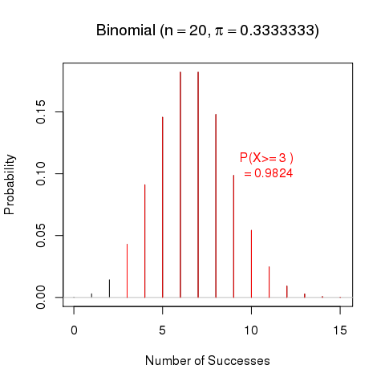

```
Probability 3 and above = 0.9824074
```

```
[1] 0.9824074
```

```r
library(ImproveISCAM)
binomprob(3,20,1/3,lower.tail = FALSE)
```

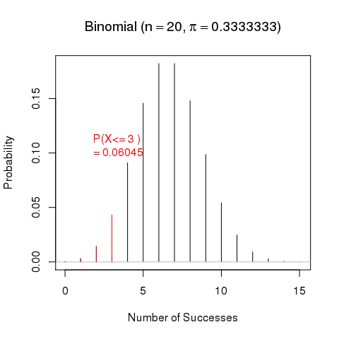

```
Probability 3 and below = 0.06044646
```

```
[1] 0.06044646
```

```r
binomprob(3,20,1/3,lower.tail = TRUE)
```

As you see from my example, `binomial(k,n,pi,TRUE/FALSE)`. `lower.tail = FALSE` indicate right tail probability of binomial random variable. `lower.tail= TRUE` indicate left tail probability of binomial random variable.

### Exact Binomial Test and Confidence Interval.

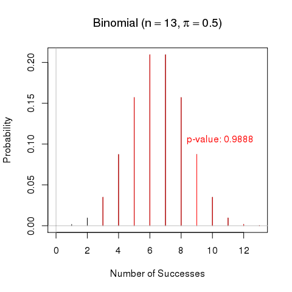

```
Exact Binomial Test

Data: observed successes = 3, sample size = 13, sample proportion = 0.2308

Null hypothesis       : pi = 0.5
Alternative hypothesis: pi > 0.5
p-value: 0.98877
```

```r
binomtest(3, 13, 1/2, "greater")
```

`binomtest(k,n,pi,"greeter/less/tow.sided")` will help you determined right/left tail probability of binomial random variable. As you see the result, it already show null hypothesis and alternative hypothesis with p-value. So you can conclude with your result either reject null hypothesis or not.

For example :

```r
binomtest(3, 13, conf.level=c(90,95))
```

```
Exact Binomial Test

Data: observed successes = 3, sample size = 13, sample proportion = 0.2308

90 % Confidence interval for pi: ( 0.06605 , 0.49465 )
95 % Confidence interval for pi: ( 0.050381 , 0.53813 )
```

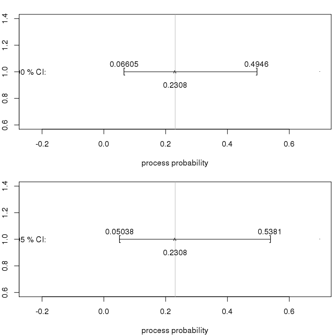

`binomtest(k, conf.level = c( , ))` will calculate confidence interval for you.

### Normal Probability

The normal distribution is a probability distribution that associates the normal random variable X with a cumulative probability.

For example :

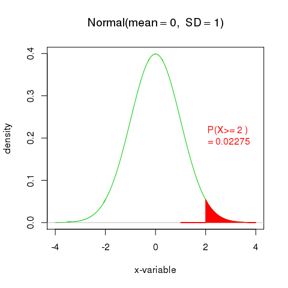

```
probability: 0.02275
```

```r
normprob(2, direction="above")
```

`normporb(x, mu, sigma, "above/below/outside/between")` will help calculate right.left/two-tailed probability and probability between tow values in normal distribution.

### Inverse Normal Probability

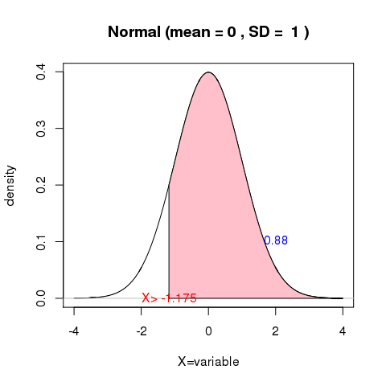

```
The observation with 0.88 probability above is -1.175
```

```r
InNorm(0.88, direction="above")
```

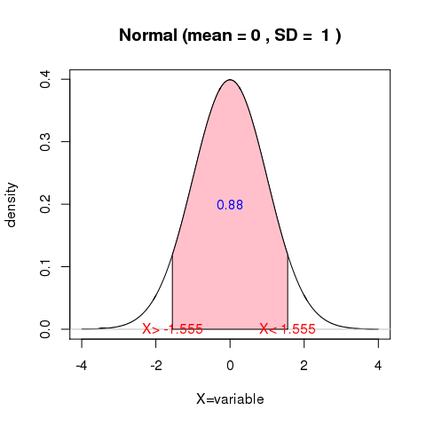

```
There is 0.88 probability between -1.555 and 1.555
```

```r
InNorm(0.88, direction="between")
```

`InNorm(probability, direction="above/below/outside/between")` will calculate your z-score value with right/left/two-tail probability and probability between tow values.

### Normal(z-test) Approimation for One Propotion and Confidence Interval(CI)

```r
propztest(2.67, 18, 1/3, "greater")
```

```
One Proportion z test

Data: observed successes = 2.67, sample size = 18, sample proportion = 0.1483

Null hypothesis       : pi = 0.333333333333333
Alternative hypothesis: pi > 0.333333333333333
z-statistic: -1.67
p-value: 0.952
```

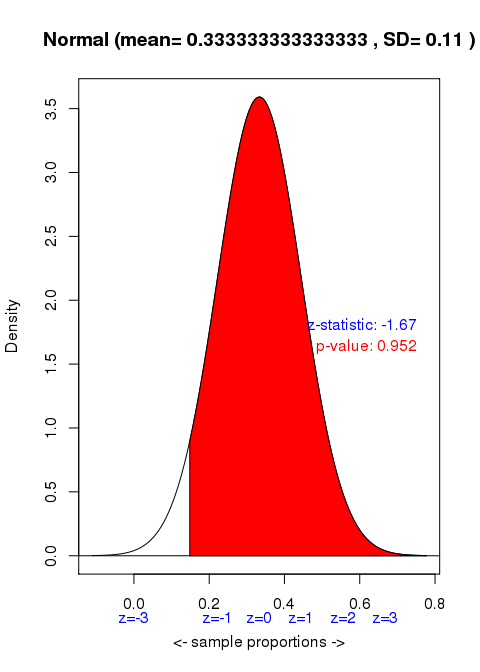

`propztest(k,n,pi, "greater/below/less/two.sided/")` will find right/left/two-tailed probabilty of proportion using Normal z-test.

```r
propztest(3, 13, conf.level=c(90,95))
```

```
One Proportion z test

Data: observed successes = 3, sample size = 13, sample proportion = 0.2308

90 % Confidence interval for pi: ( 0.03858241 ,  0.4230176 )
95 % Confidence interval for pi: ( 0.001758618 ,  0.4598414 )
```

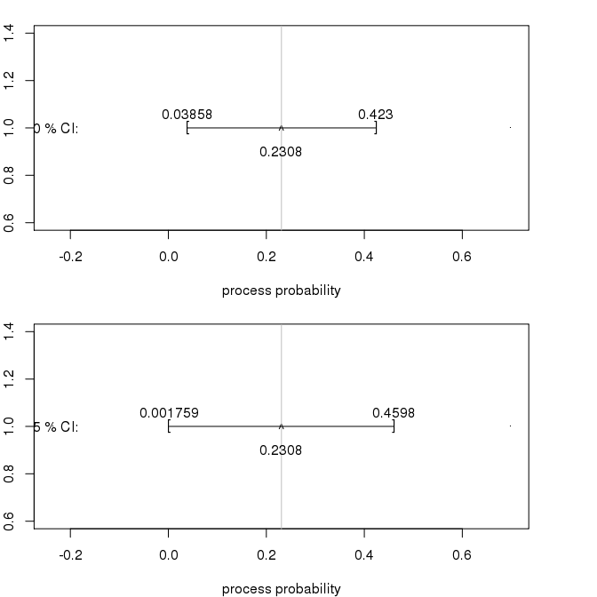

`propztest(k,n,conf.level=c( ,))` will hlep you find normal confidce interval.